# Sharpe Ratio and Portfolio Values

```python
import pandas as pd
```

```python
import quandl
```

## Create a Portfolio

```python
start = pd.to_datetime('2012-01-01')
end = pd.to_datetime('2017-01-01')
```

```python
# Grabbing a bunch of tech stocks for our portfolio
aapl = quandl.get('WIKI/AAPL.11',start_date=start,end_date=end)
cisco = quandl.get('WIKI/CSCO.11',start_date=start,end_date=end)
ibm = quandl.get('WIKI/IBM.11',start_date=start,end_date=end)
amzn = quandl.get('WIKI/AMZN.11',start_date=start,end_date=end)
```

```python
# Alternative
# aapl = pd.read_csv('AAPL_CLOSE',index_col='Date',parse_dates=True)
# cisco = pd.read_csv('CISCO_CLOSE',index_col='Date',parse_dates=True)
# ibm = pd.read_csv('IBM_CLOSE',index_col='Date',parse_dates=True)
# amzn = pd.read_csv('AMZN_CLOSE',index_col='Date',parse_dates=True)
```

```python
aapl.to_csv('AAPL_CLOSE')
cisco.to_csv('CISCO_CLOSE')
ibm.to_csv('IBM_CLOSE')
amzn.to_csv('AMZN_CLOSE')
```

## Normalize Prices

This is the same as cumulative daily returns

```python
# Example
aapl.iloc[0]['Adj. Close']
```

```
53.063217800140997
```

```python
for stock_df in (aapl,cisco,ibm,amzn):
    stock_df['Normed Return'] = stock_df['Adj. Close']/stock_df.iloc[0]['Adj. Close']
```

```python
aapl.head()
```

| Date | Adj. Close | Normed Return |
| --- | --- | --- |
| 2012-01-03 | 53.063218 | 1.000000 |
| 2012-01-04 | 53.348386 | 1.005374 |
| 2012-01-05 | 53.940658 | 1.016536 |
| 2012-01-06 | 54.504543 | 1.027162 |
| 2012-01-09 | 54.418089 | 1.025533 |

```python
aapl.tail()
```

| Date | Adj. Close | Normed Return |
| --- | --- | --- |
| 2016-12-23 | 115.547742 | 2.177549 |
| 2016-12-27 | 116.281568 | 2.191378 |
| 2016-12-28 | 115.785740 | 2.182034 |
| 2016-12-29 | 115.755990 | 2.181473 |
| 2016-12-30 | 114.853583 | 2.164467 |

## Allocations

Let's have these values be reflected by multiplying our Norme Return by out Allocations

```python
for stock_df,allo in zip([aapl,cisco,ibm,amzn],[.3,.2,.4,.1]):
    stock_df['Allocation'] = stock_df['Normed Return']*allo
```

```python
aapl.head()
```

| Date | Adj. Close | Normed Return | Allocation |
| --- | --- | --- | --- |
| 2012-01-03 | 53.063218 | 1.000000 | 0.300000 |
| 2012-01-04 | 53.348386 | 1.005374 | 0.301612 |
| 2012-01-05 | 53.940658 | 1.016536 | 0.304961 |
| 2012-01-06 | 54.504543 | 1.027162 | 0.308149 |
| 2012-01-09 | 54.418089 | 1.025533 | 0.307660 |

## Investment

Let's pretend we invested a million dollars in this portfolio

```python
for stock_df in [aapl,cisco,ibm,amzn]:
    stock_df['Position Values'] = stock_df['Allocation']*1000000
```

## Total Portfolio Value

```python
portfolio_val = pd.concat([aapl['Position Values'],cisco['Position Values'],ibm['Position Values'],amzn['Position Values']],axis=1)
```

```python
portfolio_val.head()
```

| Date | Position Values | Position Values | Position Values | Position Values |
| --- | --- | --- | --- | --- |
| 2012-01-03 | 300000.000000 | 200000.000000 | 400000.000000 | 100000.000000 |
| 2012-01-04 | 301612.236461 | 203864.734300 | 398368.223296 | 99150.980283 |
| 2012-01-05 | 304960.727573 | 203113.258186 | 396478.797638 | 99206.836843 |
| 2012-01-06 | 308148.724558 | 202361.782072 | 391926.999463 | 101999.664861 |
| 2012-01-09 | 307659.946988 | 203650.026838 | 389887.278583 | 99737.474166 |

```python
portfolio_val.columns = ['AAPL Pos','CISCO Pos','IBM Pos','AMZN Pos']
```

```python
portfolio_val.head()
```

| Date | AAPL Pos | CISCO Pos | IBM Pos | AMZN Pos |
| --- | --- | --- | --- | --- |
| 2012-01-03 | 300000.000000 | 200000.000000 | 400000.000000 | 100000.000000 |
| 2012-01-04 | 301612.236461 | 203864.734300 | 398368.223296 | 99150.980283 |
| 2012-01-05 | 304960.727573 | 203113.258186 | 396478.797638 | 99206.836843 |
| 2012-01-06 | 308148.724558 | 202361.782072 | 391926.999463 | 101999.664861 |
| 2012-01-09 | 307659.946988 | 203650.026838 | 389887.278583 | 99737.474166 |

```python
portfolio_val['Total Pos'] = portfolio_val.sum(axis=1)
```

```python
portfolio_val.head()
```

| Date | AAPL Pos | CISCO Pos | IBM Pos | AMZN Pos | Total Pos |
| --- | --- | --- | --- | --- | --- |
| 2012-01-03 | 300000.000000 | 200000.000000 | 400000.000000 | 100000.000000 | 1.000000e+06 |
| 2012-01-04 | 301612.236461 | 203864.734300 | 398368.223296 | 99150.980283 | 1.002996e+06 |
| 2012-01-05 | 304960.727573 | 203113.258186 | 396478.797638 | 99206.836843 | 1.003760e+06 |
| 2012-01-06 | 308148.724558 | 202361.782072 | 391926.999463 | 101999.664861 | 1.004437e+06 |
| 2012-01-09 | 307659.946988 | 203650.026838 | 389887.278583 | 99737.474166 | 1.000935e+06 |

```python
import matplotlib.pyplot as plt
%matplotlib inline
```

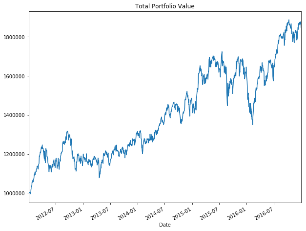

```python
portfolio_val['Total Pos'].plot(figsize=(10,8))
plt.title('Total Portfolio Value')
```

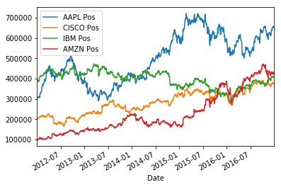

```python
portfolio_val.drop('Total Pos',axis=1).plot(kind='line')
```

```python
portfolio_val.tail()
```

| Date | AAPL Pos | CISCO Pos | IBM Pos | AMZN Pos | Total Pos |
| --- | --- | --- | --- | --- | --- |
| 2016-12-23 | 653264.617079 | 377469.015679 | 407359.955612 | 424839.412389 | 1.862933e+06 |
| 2016-12-27 | 657413.396830 | 379323.596496 | 408410.671112 | 430877.506563 | 1.876025e+06 |
| 2016-12-28 | 654610.167268 | 376108.989746 | 406089.322915 | 431285.259454 | 1.868094e+06 |
| 2016-12-29 | 654441.973495 | 376603.544631 | 407091.167926 | 427386.471541 | 1.865523e+06 |
| 2016-12-30 | 649340.095692 | 373636.215323 | 405600.618032 | 418851.589119 | 1.847429e+06 |

# Portfolio Statistics

### Daily Returns

```python
portfolio_val['Daily Return'] = portfolio_val['Total Pos'].pct_change(1)
```

### Cumulative Return

```python
cum_ret = 100 * (portfolio_val['Total Pos'][-1]/portfolio_val['Total Pos'][0] -1 )
print('Our return {} was percent!'.format(cum_ret))
```

```
Our return 84.74285181665459 was percent!
```

### Avg Daily Return

```python
portfolio_val['Daily Return'].mean()
```

```
0.0005442330716215298
```

### Std Daily Return

```python
portfolio_val['Daily Return'].std()
```

```
0.010568287769162561
```

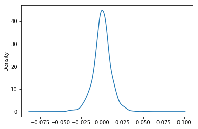

```python
portfolio_val['Daily Return'].plot(kind='kde')
```

# Sharpe Ratio

The Sharpe Ratio is a measure for calculating risk-adjusted return, and this ratio has become the industry standard for such calculations.

Sharpe ratio = (Mean portfolio return − Risk-free rate)/Standard deviation of portfolio return

The original Sharpe Ratio

Annualized Sharpe Ratio = K-value * SR

K-values for various sampling rates:

- Daily = sqrt(252)
- Weekly = sqrt(52)
- Monthly = sqrt(12)

Since I'm based in the USA, I will use a very low risk-free rate (the rate you would get if you just put your money in a bank, its currently very low in the USA, let's just say its ~0% return). If you are in a different country with higher rates for your trading currency, you can use this trick to convert a yearly rate with a daily rate:

daily_rate = ((1.0 + yearly_rate)**(1/252))-1

Other values people use are things like the 3-month treasury bill or [LIBOR](http://www.investopedia.com/terms/l/libor.asp).

Read more: Sharpe Ratio http://www.investopedia.com/terms/s/sharperatio

```python
SR = portfolio_val['Daily Return'].mean()/portfolio_val['Daily Return'].std()
```

```python
SR
```

```
0.05149680662647732
```

```python
ASR = (252**0.5)*SR
```

```python
ASR
```

```
0.8174864618858524
```

```python
portfolio_val['Daily Return'].std()
```

```
0.010568287769162561
```

```python
portfolio_val['Daily Return'].mean()
```

```
0.0005442330716215298
```

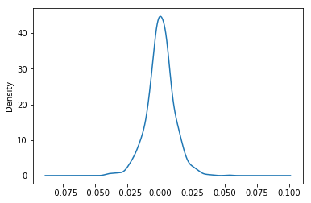

```python
portfolio_val['Daily Return'].plot('kde')
```

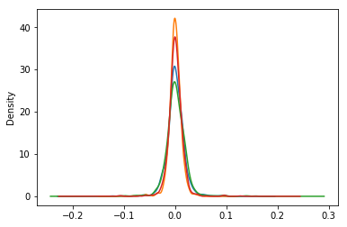

```python
aapl['Adj. Close'].pct_change(1).plot('kde')
ibm['Adj. Close'].pct_change(1).plot('kde')
amzn['Adj. Close'].pct_change(1).plot('kde')
cisco['Adj. Close'].pct_change(1).plot('kde')
```

# Portfolio Optimization

“Modern Portfolio Theory (MPT), a hypothesis put forth by Harry Markowitz in his paper “Portfolio Selection,” (published in 1952 by the Journal of Finance) is an investment theory based on the idea that risk-averse investors can construct portfolios to optimize or maximize expected return based on a given level of market risk, emphasizing that risk is an inherent part of higher reward. It is one of the most important and influential economic theories dealing with finance and investment.

## Monte Carlo Simulation for Optimization Search

We could randomly try to find the optimal portfolio balance using Monte Carlo simulation

```python
import numpy as np
import pandas as pd
import matplotlib.pyplot as plt
%matplotlib inline
```

```python
# Download and get Daily Returns
aapl = pd.read_csv('AAPL_CLOSE',index_col='Date',parse_dates=True)
cisco = pd.read_csv('CISCO_CLOSE',index_col='Date',parse_dates=True)
ibm = pd.read_csv('IBM_CLOSE',index_col='Date',parse_dates=True)
amzn = pd.read_csv('AMZN_CLOSE',index_col='Date',parse_dates=True)
```

```python
stocks = pd.concat([aapl,cisco,ibm,amzn],axis=1)
stocks.columns = ['aapl','cisco','ibm','amzn']
```

```python
stocks.head()
```

| Date | aapl | cisco | ibm | amzn |
| --- | --- | --- | --- | --- |
| 2012-01-03 | 53.063218 | 15.752778 | 160.830881 | 179.03 |
| 2012-01-04 | 53.348386 | 16.057180 | 160.174781 | 177.51 |
| 2012-01-05 | 53.940658 | 15.997991 | 159.415086 | 177.61 |
| 2012-01-06 | 54.504543 | 15.938801 | 157.584912 | 182.61 |
| 2012-01-09 | 54.418089 | 16.040268 | 156.764786 | 178.56 |

```python
mean_daily_ret = stocks.pct_change(1).mean()
mean_daily_ret
```

```
aapl     0.000750
cisco    0.000599
ibm      0.000081
amzn     0.001328
dtype: float64
```

```python
stocks.pct_change(1).corr()
```

|  | aapl | cisco | ibm | amzn |
| --- | --- | --- | --- | --- |
| aapl | 1.000000 | 0.301990 | 0.297498 | 0.235487 |
| cisco | 0.301990 | 1.000000 | 0.424672 | 0.284470 |
| ibm | 0.297498 | 0.424672 | 1.000000 | 0.258492 |
| amzn | 0.235487 | 0.284470 | 0.258492 | 1.000000 |

# Simulating Thousands of Possible Allocations

```python
stocks.head()
```

| Date | aapl | cisco | ibm | amzn |
| --- | --- | --- | --- | --- |
| 2012-01-03 | 53.063218 | 15.752778 | 160.830881 | 179.03 |
| 2012-01-04 | 53.348386 | 16.057180 | 160.174781 | 177.51 |
| 2012-01-05 | 53.940658 | 15.997991 | 159.415086 | 177.61 |
| 2012-01-06 | 54.504543 | 15.938801 | 157.584912 | 182.61 |
| 2012-01-09 | 54.418089 | 16.040268 | 156.764786 | 178.56 |

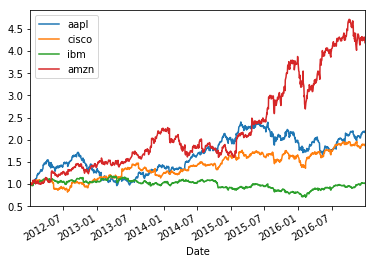

```python
stock_normed = stocks/stocks.iloc[0]
stock_normed.plot()
```

```python
stock_daily_ret = stocks.pct_change(1)
stock_daily_ret.head()
```

| Date | aapl | cisco | ibm | amzn |
| --- | --- | --- | --- | --- |
| 2012-01-03 | NaN | NaN | NaN | NaN |
| 2012-01-04 | 0.005374 | 0.019324 | -0.004079 | -0.008490 |
| 2012-01-05 | 0.011102 | -0.003686 | -0.004743 | 0.000563 |
| 2012-01-06 | 0.010454 | -0.003700 | -0.011481 | 0.028152 |
| 2012-01-09 | -0.001586 | 0.006366 | -0.005204 | -0.022178 |

## Log Returns vs Arithmetic Returns

We will now switch over to using log returns instead of arithmetic returns, for many of our use cases they are almost the same,but most technical analyses require detrending/normalizing the time series and using log returns is a nice way to do that. Log returns are convenient to work with in many of the algorithms we will encounter.

For a full analysis of why we use log returns, check [this great article](https://quantivity.wordpress.com/2011/02/21/why-log-returns/).

```python
log_ret = np.log(stocks/stocks.shift(1))
log_ret.head()
```

| Date | aapl | cisco | ibm | amzn |
| --- | --- | --- | --- | --- |
| 2012-01-03 | NaN | NaN | NaN | NaN |
| 2012-01-04 | 0.005360 | 0.019139 | -0.004088 | -0.008526 |
| 2012-01-05 | 0.011041 | -0.003693 | -0.004754 | 0.000563 |
| 2012-01-06 | 0.010400 | -0.003707 | -0.011547 | 0.027763 |
| 2012-01-09 | -0.001587 | 0.006346 | -0.005218 | -0.022428 |

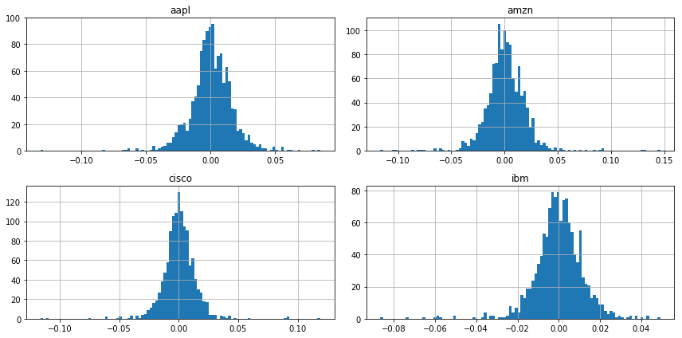

```python
log_ret.hist(bins=100,figsize=(12,6));
plt.tight_layout()
```

```python
log_ret.describe().transpose()
```

|  | count | mean | std | min | 25% | 50% | 75% | max |
| --- | --- | --- | --- | --- | --- | --- | --- | --- |
| aapl | 1257.0 | 0.000614 | 0.016466 | -0.131875 | -0.007358 | 0.000455 | 0.009724 | 0.085022 |
| cisco | 1257.0 | 0.000497 | 0.014279 | -0.116091 | -0.006240 | 0.000213 | 0.007634 | 0.118862 |
| ibm | 1257.0 | 0.000011 | 0.011819 | -0.086419 | -0.005873 | 0.000049 | 0.006477 | 0.049130 |
| amzn | 1257.0 | 0.001139 | 0.019362 | -0.116503 | -0.008534 | 0.000563 | 0.011407 | 0.146225 |

```python
log_ret.mean() * 252
```

```
aapl     0.154803
cisco    0.125291
ibm      0.002788
amzn     0.287153
dtype: float64
```

```python
# Compute pairwise covariance of columns
log_ret.cov()
```

|  | aapl | cisco | ibm | amzn |
| --- | --- | --- | --- | --- |
| aapl | 0.000271 | 0.000071 | 0.000057 | 0.000075 |
| cisco | 0.000071 | 0.000204 | 0.000072 | 0.000079 |
| ibm | 0.000057 | 0.000072 | 0.000140 | 0.000059 |
| amzn | 0.000075 | 0.000079 | 0.000059 | 0.000375 |

```python
log_ret.cov()*252 # multiply by days
```

|  | aapl | cisco | ibm | amzn |
| --- | --- | --- | --- | --- |
| aapl | 0.068326 | 0.017854 | 0.014464 | 0.018986 |
| cisco | 0.017854 | 0.051381 | 0.018029 | 0.019956 |
| ibm | 0.014464 | 0.018029 | 0.035203 | 0.014939 |
| amzn | 0.018986 | 0.019956 | 0.014939 | 0.094470 |

## Single Run for Some Random Allocation

```python
# Set seed (optional)
np.random.seed(101)

# Stock Columns
print('Stocks')
print(stocks.columns)
print('\n')

# Create Random Weights
print('Creating Random Weights')
weights = np.array(np.random.random(4))
print(weights)
print('\n')

# Rebalance Weights
print('Rebalance to sum to 1.0')
weights = weights / np.sum(weights)
print(weights)
print('\n')

# Expected Return
print('Expected Portfolio Return')
exp_ret = np.sum(log_ret.mean() * weights) *252
print(exp_ret)
print('\n')

# Expected Variance
print('Expected Volatility')
exp_vol = np.sqrt(np.dot(weights.T, np.dot(log_ret.cov() * 252, weights)))
print(exp_vol)
print('\n')

# Sharpe Ratio
SR = exp_ret/exp_vol
print('Sharpe Ratio')
print(SR)
```

```
Stocks
Index(['aapl', 'cisco', 'ibm', 'amzn'], dtype='object')


Creating Random Weights
[ 0.51639863  0.57066759  0.02847423  0.17152166]


Rebalance to sum to 1.0
[ 0.40122278  0.44338777  0.02212343  0.13326603]


Expected Portfolio Return
0.15599272049632004


Expected Volatility
0.185026495659


Sharpe Ratio
0.843083148393
```

Great! Now we can just run this many times over!

```python
num_ports = 15000

all_weights = np.zeros((num_ports,len(stocks.columns)))
ret_arr = np.zeros(num_ports)
vol_arr = np.zeros(num_ports)
sharpe_arr = np.zeros(num_ports)

for ind in range(num_ports):

    # Create Random Weights
    weights = np.array(np.random.random(4))

    # Rebalance Weights
    weights = weights / np.sum(weights)

    # Save Weights
    all_weights[ind,:] = weights

    # Expected Return
    ret_arr[ind] = np.sum((log_ret.mean() * weights) *252)

    # Expected Variance
    vol_arr[ind] = np.sqrt(np.dot(weights.T, np.dot(log_ret.cov() * 252, weights)))

    # Sharpe Ratio
    sharpe_arr[ind] = ret_arr[ind]/vol_arr[ind]
```

```python
sharpe_arr.max()
```

```
1.0303260551271067
```

```python
sharpe_arr.argmax()
```

```
1419
```

```python
all_weights[1419,:]
```

```
array([ 0.26188068,  0.20759516,  0.00110226,  0.5294219 ])
```

```python
max_sr_ret = ret_arr[1419]
max_sr_vol = vol_arr[1419]
```

## Plotting the data

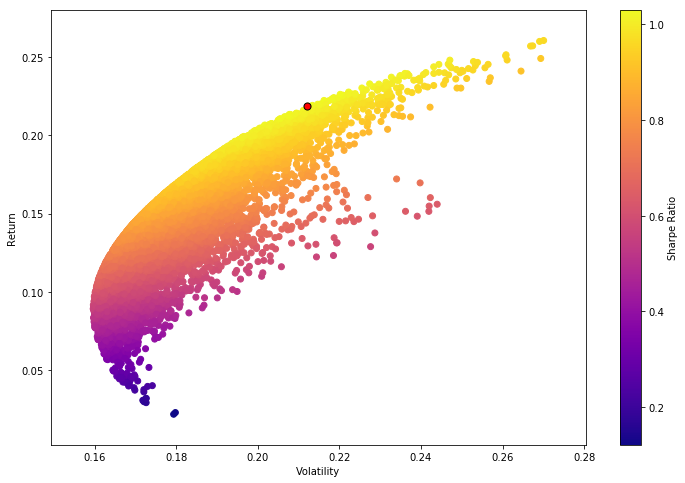

```python
plt.figure(figsize=(12,8))
plt.scatter(vol_arr,ret_arr,c=sharpe_arr,cmap='plasma')
plt.colorbar(label='Sharpe Ratio')
plt.xlabel('Volatility')
plt.ylabel('Return')

# Add red dot for max SR
plt.scatter(max_sr_vol,max_sr_ret,c='red',s=50,edgecolors='black')
```

# Mathematical Optimization

There are much better ways to find good allocation weights than just guess and check! We can use optimization functions to find the ideal weights mathematically!

### Functionalize Return and SR operations

```python
def get_ret_vol_sr(weights):
    """
    Takes in weights, returns array or return,volatility, sharpe ratio
    """
    weights = np.array(weights)
    ret = np.sum(log_ret.mean() * weights) * 252
    vol = np.sqrt(np.dot(weights.T, np.dot(log_ret.cov() * 252, weights)))
    sr = ret/vol
    return np.array([ret,vol,sr])
```

```python
from scipy.optimize import minimize
```

To fully understand all the parameters, check out: https://docs.scipy.org/doc/scipy/reference/generated/scipy.optimize.minimize.html

```python
help(minimize)
```

```
Help on function minimize in module scipy.optimize._minimize:

minimize(fun, x0, args=(), method=None, jac=None, hess=None, hessp=None, bounds=None, constraints=(), tol=None, callback=None, options=None)
    Minimization of scalar function of one or more variables.

    In general, the optimization problems are of the form::

        minimize f(x) subject to

        g_i(x) >= 0,  i = 1,...,m
        h_j(x)  = 0,  j = 1,...,p

    where x is a vector of one or more variables.
    ``g_i(x)`` are the inequality constraints.
    ``h_j(x)`` are the equality constrains.

    Optionally, the lower and upper bounds for each element in x can also be
    specified using the `bounds` argument.

    Parameters
    ----------
    fun : callable
        Objective function.
    x0 : ndarray
        Initial guess.
    args : tuple, optional
        Extra arguments passed to the objective function and its
        derivatives (Jacobian, Hessian).
    method : str or callable, optional
        Type of solver.  Should be one of

            - 'Nelder-Mead' :ref:`(see here) <optimize.minimize-neldermead>`
            - 'Powell'      :ref:`(see here) <optimize.minimize-powell>`
            - 'CG'          :ref:`(see here) <optimize.minimize-cg>`
            - 'BFGS'        :ref:`(see here) <optimize.minimize-bfgs>`
            - 'Newton-CG'   :ref:`(see here) <optimize.minimize-newtoncg>`
            - 'L-BFGS-B'    :ref:`(see here) <optimize.minimize-lbfgsb>`
            - 'TNC'         :ref:`(see here) <optimize.minimize-tnc>`
            - 'COBYLA'      :ref:`(see here) <optimize.minimize-cobyla>`
            - 'SLSQP'       :ref:`(see here) <optimize.minimize-slsqp>`
```

[output cut: 261 more lines]

```

    >>> cons = ({'type': 'ineq', 'fun': lambda x:  x[0] - 2 * x[1] + 2},
    ...         {'type': 'ineq', 'fun': lambda x: -x[0] - 2 * x[1] + 6},
    ...         {'type': 'ineq', 'fun': lambda x: -x[0] + 2 * x[1] + 2})

    And variables must be positive, hence the following bounds:

    >>> bnds = ((0, None), (0, None))

    The optimization problem is solved using the SLSQP method as:

    >>> res = minimize(fun, (2, 0), method='SLSQP', bounds=bnds,
    ...                constraints=cons)

    It should converge to the theoretical solution (1.4 ,1.7).
```

Optimization works as a minimization function, since we actually want to maximize the Sharpe Ratio, we will need to turn it negative so we can minimize the negative sharpe (same as maximizing the postive sharpe)

```python
def neg_sharpe(weights):
    return  get_ret_vol_sr(weights)[2] * -1
```

```python
# Contraints
def check_sum(weights):
    '''
    Returns 0 if sum of weights is 1.0
    '''
    return np.sum(weights) - 1
```

```python
# By convention of minimize function it should be a function that returns zero for conditions
cons = ({'type':'eq','fun': check_sum})
```

```python
# 0-1 bounds for each weight
bounds = ((0, 1), (0, 1), (0, 1), (0, 1))
```

```python
# Initial Guess (equal distribution)
init_guess = [0.25,0.25,0.25,0.25]
```

```python
# Sequential Least SQuares Programming (SLSQP).
opt_results = minimize(neg_sharpe,init_guess,method='SLSQP',bounds=bounds,constraints=cons)
```

```python
opt_results
```

```
     fun: -1.030716870334955
     jac: array([  5.64455986e-05,   4.18275595e-05,   3.39921728e-01,
        -4.45097685e-05])
 message: 'Optimization terminated successfully.'
    nfev: 42
     nit: 7
    njev: 7
  status: 0
 success: True
       x: array([  2.66289778e-01,   2.04189819e-01,   9.24621165e-17,
         5.29520404e-01])
```

```python
opt_results.x
```

```
array([  2.66289778e-01,   2.04189819e-01,   9.24621165e-17,
         5.29520404e-01])
```

```python
get_ret_vol_sr(opt_results.x)
```

```
array([ 0.21885915,  0.21233683,  1.03071687])
```

# All Optimal Portfolios (Efficient Frontier)

The efficient frontier is the set of optimal portfolios that offers the highest expected return for a defined level of risk or the lowest risk for a given level of expected return. Portfolios that lie below the efficient frontier are sub-optimal, because they do not provide enough return for the level of risk. Portfolios that cluster to the right of the efficient frontier are also sub-optimal, because they have a higher level of risk for the defined rate of return.

Efficient Frontier http://www.investopedia.com/terms/e/efficientfrontier

```python
# Our returns go from 0 to somewhere along 0.3
# Create a linspace number of points to calculate x on
frontier_y = np.linspace(0,0.3,100) # Change 100 to a lower number for slower computers!
```

```python
def minimize_volatility(weights):
    return  get_ret_vol_sr(weights)[1]
```

```python
frontier_volatility = []

for possible_return in frontier_y:
    # function for return
    cons = ({'type':'eq','fun': check_sum},
            {'type':'eq','fun': lambda w: get_ret_vol_sr(w)[0] - possible_return})

    result = minimize(minimize_volatility,init_guess,method='SLSQP',bounds=bounds,constraints=cons)

    frontier_volatility.append(result['fun'])
```

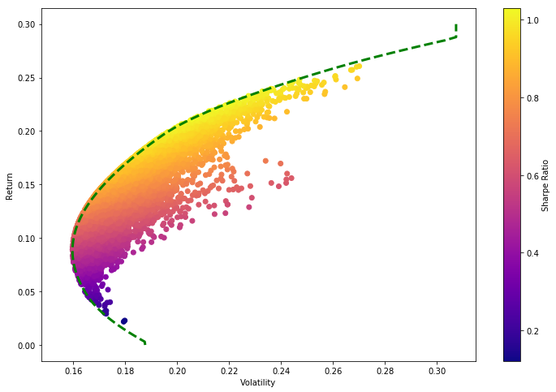

```python
plt.figure(figsize=(12,8))
plt.scatter(vol_arr,ret_arr,c=sharpe_arr,cmap='plasma')
plt.colorbar(label='Sharpe Ratio')
plt.xlabel('Volatility')
plt.ylabel('Return')



# Add frontier line
plt.plot(frontier_volatility,frontier_y,'g--',linewidth=3)
```

# Great Job!

```python
import numpy as np
np.sqrt(252)* (np.mean(.001-0.0002)/.001)
```

```
12.699606293110037
```

# Portfolio Optimization

“Modern Portfolio Theory (MPT), a hypothesis put forth by Harry Markowitz in his paper “Portfolio Selection,” (published in 1952 by the Journal of Finance) is an investment theory based on the idea that risk-averse investors can construct portfolios to optimize or maximize expected return based on a given level of market risk, emphasizing that risk is an inherent part of higher reward. It is one of the most important and influential economic theories dealing with finance and investment.

## Monte Carlo Simulation for Optimization Search

We could randomly try to find the optimal portfolio balance using Monte Carlo simulation

```python
import numpy as np
import pandas as pd
import matplotlib.pyplot as plt
%matplotlib inline
```

```python
# Download and get Daily Returns
aapl = pd.read_csv('AAPL_CLOSE',index_col='Date',parse_dates=True)
cisco = pd.read_csv('CISCO_CLOSE',index_col='Date',parse_dates=True)
ibm = pd.read_csv('IBM_CLOSE',index_col='Date',parse_dates=True)
amzn = pd.read_csv('AMZN_CLOSE',index_col='Date',parse_dates=True)
```

```python
stocks = pd.concat([aapl,cisco,ibm,amzn],axis=1)
stocks.columns = ['aapl','cisco','ibm','amzn']
```

```python
stocks.head()
```

| Date | aapl | cisco | ibm | amzn |
| --- | --- | --- | --- | --- |
| 2012-01-03 | 53.063218 | 15.752778 | 160.830881 | 179.03 |
| 2012-01-04 | 53.348386 | 16.057180 | 160.174781 | 177.51 |
| 2012-01-05 | 53.940658 | 15.997991 | 159.415086 | 177.61 |
| 2012-01-06 | 54.504543 | 15.938801 | 157.584912 | 182.61 |
| 2012-01-09 | 54.418089 | 16.040268 | 156.764786 | 178.56 |

```python
mean_daily_ret = stocks.pct_change(1).mean()
mean_daily_ret
```

```
aapl     0.000750
cisco    0.000599
ibm      0.000081
amzn     0.001328
dtype: float64
```

```python
stocks.pct_change(1).corr()
```

|  | aapl | cisco | ibm | amzn |
| --- | --- | --- | --- | --- |
| aapl | 1.000000 | 0.301990 | 0.297498 | 0.235487 |
| cisco | 0.301990 | 1.000000 | 0.424672 | 0.284470 |
| ibm | 0.297498 | 0.424672 | 1.000000 | 0.258492 |
| amzn | 0.235487 | 0.284470 | 0.258492 | 1.000000 |

# Simulating Thousands of Possible Allocations

```python
stocks.head()
```

| Date | aapl | cisco | ibm | amzn |
| --- | --- | --- | --- | --- |
| 2012-01-03 | 53.063218 | 15.752778 | 160.830881 | 179.03 |
| 2012-01-04 | 53.348386 | 16.057180 | 160.174781 | 177.51 |
| 2012-01-05 | 53.940658 | 15.997991 | 159.415086 | 177.61 |
| 2012-01-06 | 54.504543 | 15.938801 | 157.584912 | 182.61 |
| 2012-01-09 | 54.418089 | 16.040268 | 156.764786 | 178.56 |

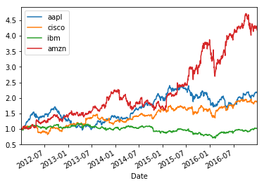

```python
stock_normed = stocks/stocks.iloc[0]
stock_normed.plot()
```

```python
stock_daily_ret = stocks.pct_change(1)
stock_daily_ret.head()
```

| Date | aapl | cisco | ibm | amzn |
| --- | --- | --- | --- | --- |
| 2012-01-03 | NaN | NaN | NaN | NaN |
| 2012-01-04 | 0.005374 | 0.019324 | -0.004079 | -0.008490 |
| 2012-01-05 | 0.011102 | -0.003686 | -0.004743 | 0.000563 |
| 2012-01-06 | 0.010454 | -0.003700 | -0.011481 | 0.028152 |
| 2012-01-09 | -0.001586 | 0.006366 | -0.005204 | -0.022178 |

## Log Returns vs Arithmetic Returns

We will now switch over to using log returns instead of arithmetic returns, for many of our use cases they are almost the same,but most technical analyses require detrending/normalizing the time series and using log returns is a nice way to do that. Log returns are convenient to work with in many of the algorithms we will encounter.

For a full analysis of why we use log returns, check [this great article](https://quantivity.wordpress.com/2011/02/21/why-log-returns/).

```python
log_ret = np.log(stocks/stocks.shift(1))
log_ret.head()
```

| Date | aapl | cisco | ibm | amzn |
| --- | --- | --- | --- | --- |
| 2012-01-03 | NaN | NaN | NaN | NaN |
| 2012-01-04 | 0.005360 | 0.019139 | -0.004088 | -0.008526 |
| 2012-01-05 | 0.011041 | -0.003693 | -0.004754 | 0.000563 |
| 2012-01-06 | 0.010400 | -0.003707 | -0.011547 | 0.027763 |
| 2012-01-09 | -0.001587 | 0.006346 | -0.005218 | -0.022428 |

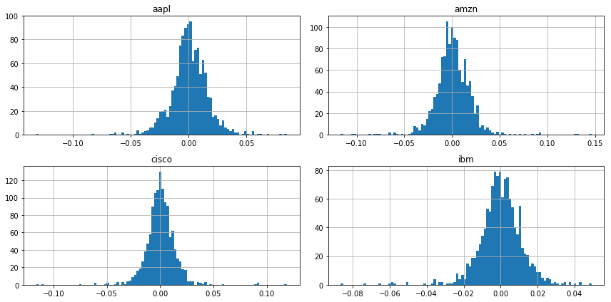

```python
log_ret.hist(bins=100,figsize=(12,6));
plt.tight_layout()
```

```python
log_ret.describe().transpose()
```

|  | count | mean | std | min | 25% | 50% | 75% | max |
| --- | --- | --- | --- | --- | --- | --- | --- | --- |
| aapl | 1257.0 | 0.000614 | 0.016466 | -0.131875 | -0.007358 | 0.000455 | 0.009724 | 0.085022 |
| cisco | 1257.0 | 0.000497 | 0.014279 | -0.116091 | -0.006240 | 0.000213 | 0.007634 | 0.118862 |
| ibm | 1257.0 | 0.000011 | 0.011819 | -0.086419 | -0.005873 | 0.000049 | 0.006477 | 0.049130 |
| amzn | 1257.0 | 0.001139 | 0.019362 | -0.116503 | -0.008534 | 0.000563 | 0.011407 | 0.146225 |

```python
log_ret.mean() * 252
```

```
aapl     0.154803
cisco    0.125291
ibm      0.002788
amzn     0.287153
dtype: float64
```

```python
# Compute pairwise covariance of columns
log_ret.cov()
```

|  | aapl | cisco | ibm | amzn |
| --- | --- | --- | --- | --- |
| aapl | 0.000271 | 0.000071 | 0.000057 | 0.000075 |
| cisco | 0.000071 | 0.000204 | 0.000072 | 0.000079 |
| ibm | 0.000057 | 0.000072 | 0.000140 | 0.000059 |
| amzn | 0.000075 | 0.000079 | 0.000059 | 0.000375 |

```python
log_ret.cov()*252 # multiply by days
```

|  | aapl | cisco | ibm | amzn |
| --- | --- | --- | --- | --- |
| aapl | 0.068326 | 0.017854 | 0.014464 | 0.018986 |
| cisco | 0.017854 | 0.051381 | 0.018029 | 0.019956 |
| ibm | 0.014464 | 0.018029 | 0.035203 | 0.014939 |
| amzn | 0.018986 | 0.019956 | 0.014939 | 0.094470 |

## Single Run for Some Random Allocation

```python
# Set seed (optional)
np.random.seed(101)

# Stock Columns
print('Stocks')
print(stocks.columns)
print('\n')

# Create Random Weights
print('Creating Random Weights')
weights = np.array(np.random.random(4))
print(weights)
print('\n')

# Rebalance Weights
print('Rebalance to sum to 1.0')
weights = weights / np.sum(weights)
print(weights)
print('\n')

# Expected Return
print('Expected Portfolio Return')
exp_ret = np.sum(log_ret.mean() * weights) *252
print(exp_ret)
print('\n')

# Expected Variance
print('Expected Volatility')
exp_vol = np.sqrt(np.dot(weights.T, np.dot(log_ret.cov() * 252, weights)))
print(exp_vol)
print('\n')

# Sharpe Ratio
SR = exp_ret/exp_vol
print('Sharpe Ratio')
print(SR)
```

```
Stocks
Index(['aapl', 'cisco', 'ibm', 'amzn'], dtype='object')


Creating Random Weights
[ 0.51639863  0.57066759  0.02847423  0.17152166]


Rebalance to sum to 1.0
[ 0.40122278  0.44338777  0.02212343  0.13326603]


Expected Portfolio Return
0.15599272049632004


Expected Volatility
0.185026495659


Sharpe Ratio
0.843083148393
```

Great! Now we can just run this many times over!

```python
num_ports = 15000

all_weights = np.zeros((num_ports,len(stocks.columns)))
ret_arr = np.zeros(num_ports)
vol_arr = np.zeros(num_ports)
sharpe_arr = np.zeros(num_ports)

for ind in range(num_ports):

    # Create Random Weights
    weights = np.array(np.random.random(4))

    # Rebalance Weights
    weights = weights / np.sum(weights)

    # Save Weights
    all_weights[ind,:] = weights

    # Expected Return
    ret_arr[ind] = np.sum((log_ret.mean() * weights) *252)

    # Expected Variance
    vol_arr[ind] = np.sqrt(np.dot(weights.T, np.dot(log_ret.cov() * 252, weights)))

    # Sharpe Ratio
    sharpe_arr[ind] = ret_arr[ind]/vol_arr[ind]
```

```python
sharpe_arr.max()
```

```
1.0303260551271067
```

```python
sharpe_arr.argmax()
```

```
1419
```

```python
all_weights[1419,:]
```

```
array([ 0.26188068,  0.20759516,  0.00110226,  0.5294219 ])
```

```python
max_sr_ret = ret_arr[1419]
max_sr_vol = vol_arr[1419]
```

## Plotting the data

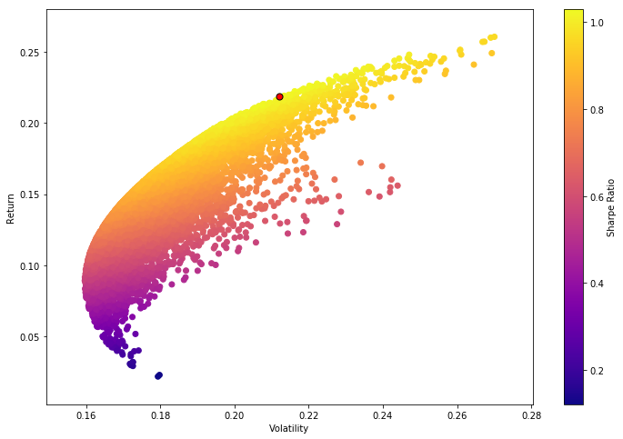

```python
plt.figure(figsize=(12,8))
plt.scatter(vol_arr,ret_arr,c=sharpe_arr,cmap='plasma')
plt.colorbar(label='Sharpe Ratio')
plt.xlabel('Volatility')
plt.ylabel('Return')

# Add red dot for max SR
plt.scatter(max_sr_vol,max_sr_ret,c='red',s=50,edgecolors='black')
```

# Mathematical Optimization

There are much better ways to find good allocation weights than just guess and check! We can use optimization functions to find the ideal weights mathematically!

### Functionalize Return and SR operations

```python
def get_ret_vol_sr(weights):
    """
    Takes in weights, returns array or return,volatility, sharpe ratio
    """
    weights = np.array(weights)
    ret = np.sum(log_ret.mean() * weights) * 252
    vol = np.sqrt(np.dot(weights.T, np.dot(log_ret.cov() * 252, weights)))
    sr = ret/vol
    return np.array([ret,vol,sr])
```

```python
from scipy.optimize import minimize
```

To fully understand all the parameters, check out: https://docs.scipy.org/doc/scipy/reference/generated/scipy.optimize.minimize.html

```python
help(minimize)
```

```
Help on function minimize in module scipy.optimize._minimize:

minimize(fun, x0, args=(), method=None, jac=None, hess=None, hessp=None, bounds=None, constraints=(), tol=None, callback=None, options=None)
    Minimization of scalar function of one or more variables.

    In general, the optimization problems are of the form::

        minimize f(x) subject to

        g_i(x) >= 0,  i = 1,...,m
        h_j(x)  = 0,  j = 1,...,p

    where x is a vector of one or more variables.
    ``g_i(x)`` are the inequality constraints.
    ``h_j(x)`` are the equality constrains.

    Optionally, the lower and upper bounds for each element in x can also be
    specified using the `bounds` argument.

    Parameters
    ----------
    fun : callable
        Objective function.
    x0 : ndarray
        Initial guess.
    args : tuple, optional
        Extra arguments passed to the objective function and its
        derivatives (Jacobian, Hessian).
    method : str or callable, optional
        Type of solver.  Should be one of

            - 'Nelder-Mead' :ref:`(see here) <optimize.minimize-neldermead>`
            - 'Powell'      :ref:`(see here) <optimize.minimize-powell>`
            - 'CG'          :ref:`(see here) <optimize.minimize-cg>`
            - 'BFGS'        :ref:`(see here) <optimize.minimize-bfgs>`
            - 'Newton-CG'   :ref:`(see here) <optimize.minimize-newtoncg>`
            - 'L-BFGS-B'    :ref:`(see here) <optimize.minimize-lbfgsb>`
            - 'TNC'         :ref:`(see here) <optimize.minimize-tnc>`
            - 'COBYLA'      :ref:`(see here) <optimize.minimize-cobyla>`
            - 'SLSQP'       :ref:`(see here) <optimize.minimize-slsqp>`
```

[output cut: 261 more lines]

```

    >>> cons = ({'type': 'ineq', 'fun': lambda x:  x[0] - 2 * x[1] + 2},
    ...         {'type': 'ineq', 'fun': lambda x: -x[0] - 2 * x[1] + 6},
    ...         {'type': 'ineq', 'fun': lambda x: -x[0] + 2 * x[1] + 2})

    And variables must be positive, hence the following bounds:

    >>> bnds = ((0, None), (0, None))

    The optimization problem is solved using the SLSQP method as:

    >>> res = minimize(fun, (2, 0), method='SLSQP', bounds=bnds,
    ...                constraints=cons)

    It should converge to the theoretical solution (1.4 ,1.7).
```

Optimization works as a minimization function, since we actually want to maximize the Sharpe Ratio, we will need to turn it negative so we can minimize the negative sharpe (same as maximizing the postive sharpe)

```python
def neg_sharpe(weights):
    return  get_ret_vol_sr(weights)[2] * -1
```

```python
# Contraints
def check_sum(weights):
    '''
    Returns 0 if sum of weights is 1.0
    '''
    return np.sum(weights) - 1
```

```python
# By convention of minimize function it should be a function that returns zero for conditions
cons = ({'type':'eq','fun': check_sum})
```

```python
# 0-1 bounds for each weight
bounds = ((0, 1), (0, 1), (0, 1), (0, 1))
```

```python
# Initial Guess (equal distribution)
init_guess = [0.25,0.25,0.25,0.25]
```

```python
# Sequential Least SQuares Programming (SLSQP).
opt_results = minimize(neg_sharpe,init_guess,method='SLSQP',bounds=bounds,constraints=cons)
```

```python
opt_results
```

```
     fun: -1.030716870334955
     jac: array([  5.64455986e-05,   4.18275595e-05,   3.39921728e-01,
        -4.45097685e-05])
 message: 'Optimization terminated successfully.'
    nfev: 42
     nit: 7
    njev: 7
  status: 0
 success: True
       x: array([  2.66289778e-01,   2.04189819e-01,   9.24621165e-17,
         5.29520404e-01])
```

```python
opt_results.x
```

```
array([  2.66289778e-01,   2.04189819e-01,   9.24621165e-17,
         5.29520404e-01])
```

```python
get_ret_vol_sr(opt_results.x)
```

```
array([ 0.21885915,  0.21233683,  1.03071687])
```

# All Optimal Portfolios (Efficient Frontier)

The efficient frontier is the set of optimal portfolios that offers the highest expected return for a defined level of risk or the lowest risk for a given level of expected return. Portfolios that lie below the efficient frontier are sub-optimal, because they do not provide enough return for the level of risk. Portfolios that cluster to the right of the efficient frontier are also sub-optimal, because they have a higher level of risk for the defined rate of return.

Efficient Frontier http://www.investopedia.com/terms/e/efficientfrontier

```python
# Our returns go from 0 to somewhere along 0.3
# Create a linspace number of points to calculate x on
frontier_y = np.linspace(0,0.3,100) # Change 100 to a lower number for slower computers!
```

```python
def minimize_volatility(weights):
    return  get_ret_vol_sr(weights)[1]
```

```python
frontier_volatility = []

for possible_return in frontier_y:
    # function for return
    cons = ({'type':'eq','fun': check_sum},
            {'type':'eq','fun': lambda w: get_ret_vol_sr(w)[0] - possible_return})

    result = minimize(minimize_volatility,init_guess,method='SLSQP',bounds=bounds,constraints=cons)

    frontier_volatility.append(result['fun'])
```

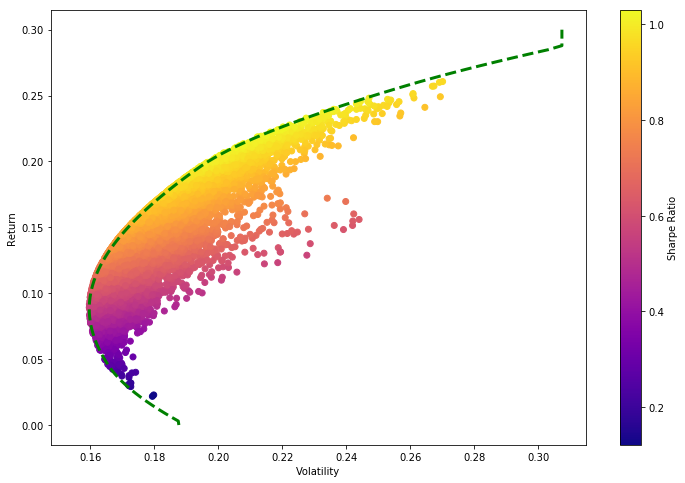

```python
plt.figure(figsize=(12,8))
plt.scatter(vol_arr,ret_arr,c=sharpe_arr,cmap='plasma')
plt.colorbar(label='Sharpe Ratio')
plt.xlabel('Volatility')
plt.ylabel('Return')



# Add frontier line
plt.plot(frontier_volatility,frontier_y,'g--',linewidth=3)
```